# Exercise 2

Jaymeee3

1. Import the dataset Women_Dresses_Reviews_Dataset.csv and name it dresses for convenience (Note: the separator is a comma).

```r
ds <- read.table("Women_Dresses_Reviews_Dataset.csv", header=T, sep=",")
```

2. Check that the nature of the imported variables has been correctly identified. If necessary, convert the variables into the appropriate format. Bonus: exclude the variables X and review_text.

```r
str(ds)
```

```
## 'data.frame':    23472 obs. of  12 variables:
##  $ X                   : int  1 2 3 4 5 6 7 8 9 10 ...
##  $ id                  : int  0 1 2 3 4 5 6 7 8 9 ...
##  $ age                 : int  40 62 47 45 37 43 83 34 49 49 ...
##  $ division_name       : chr  "General" "General Petite" "General Petite" "General Petite" ...
##  $ department_name     : chr  "Bottoms" "Tops" "Bottoms" "Bottoms" ...
##  $ class_name          : chr  "Jeans" "Blouses" "Skirts" "Pants" ...
##  $ clothing_id         : int  1028 850 993 1068 24 933 937 868 900 873 ...
##  $ title               : chr  "Amazing fit and wash" "Lovely and unique!" "Meh" "Wow" ...
##  $ review_text         : chr  "Like other reviewers i was hesitant to spend this much on a pair of jeans. however, i purchased them at  20% of"| __truncated__ "As is true of a bunch of the fall clothing photos, the colors are totally washed out in these model images whic"| __truncated__ "I so wan…
##  $ alike_feedback_count: int  0 12 3 0 0 0 4 2 4 0 ...
##  $ rating              : int  5 5 1 5 5 4 5 5 5 5 ...
##  $ flag_recommend      : int  1 1 0 1 1 1 1 1 1 1 ...
```

```r
library("tidyverse") #for pipelines and mutate
#I proceed with type casting and the exclusion of variables X and review_text

ds <- ds %>% select(-X, -review_text) %>% mutate(id=as.numeric(id),
                                                 age=as.numeric(age),
                                                 division_name=as.factor(division_name),
                                                 department_name=as.factor(department_name),
                                                 class_name=as.factor(class_name),
                                                 clothing_id=as.numeric(clothing_id),
                                                 title=as.factor(title),
                                                 alike_feedback_count=as.numeric(alike_feedback_count),
                                                 rating=as.numeric(rating),
                                                 flag_recommend=as.numeric(flag_recommend))
#let's check if it worked
str(ds)
```

```
## 'data.frame':    23472 obs. of  10 variables:
##  $ id                  : num  0 1 2 3 4 5 6 7 8 9 ...
##  $ age                 : num  40 62 47 45 37 43 83 34 49 49 ...
##  $ division_name       : Factor w/ 3 levels "General","General Petite",..: 1 2 2 2 3 1 1 1 2 1 ...
##  $ department_name     : Factor w/ 6 levels "Bottoms","Dresses",..: 1 5 1 1 3 5 5 5 5 5 ...
##  $ class_name          : Factor w/ 20 levels "Blouses","Casual bottoms",..: 8 1 16 14 19 18 18 9 5 9 ...
##  $ clothing_id         : num  1028 850 993 1068 24 ...
##  $ title               : Factor w/ 13985 levels "","\"beach business\"",..: 561 7499 7865 13893 5448 7172 932 12908 5584 1598 ...
##  $ alike_feedback_count: num  0 12 3 0 0 0 4 2 4 0 ...
##  $ rating              : num  5 5 1 5 5 4 5 5 5 5 ...
##  $ flag_recommend      : num  1 1 0 1 1 1 1 1 1 1 ...
```

```r
#the operation was successful
```

3. Create a dataset containing only the clothing items from the departments (department_name) “Tops”, “Dresses” or “Jackets”. Bonus: transform the variable flag_recommend so that 0 corresponds to “no” and 1 to “yes”.

```r
unique(ds$department_name)
```

```
## [1] Bottoms  Tops     Intimate Jackets  Dresses  Trend
## Levels: Bottoms Dresses Intimate Jackets Tops Trend
```

```r
ds2 <- ds %>% filter(department_name=="Tops") %>% mutate(flag_recommend = case_when(flag_recommend == 0 ~ 'No', flag_recommend == 1 ~ 'Yes')) %>%
  mutate(flag_recommend = factor(flag_recommend,levels = c("No", "Yes", ordered = F)))
```

4. Refer to the dataset built in Task #3. Graphically represent the variable department_name. Bonus: split the graph based on the variable flag_recommend using the function facet_wrap(~).

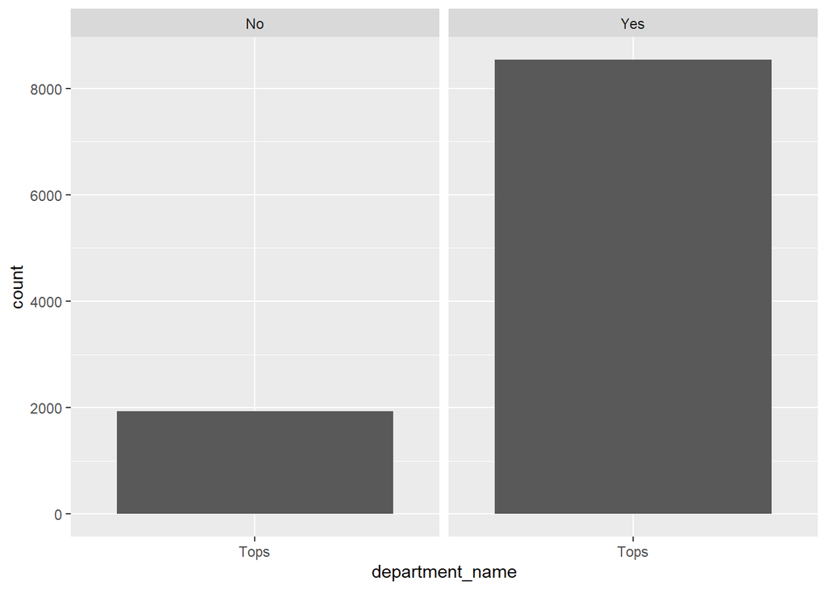

```r
ds2 %>% ggplot(aes(x=department_name)) + geom_bar() + facet_wrap(~flag_recommend)
```

5. It is hypothesized that the product division (division_name) somehow affects whether people recommend the product (flag_recommended). Build a contingency table including column percentages and marginals. What information can be gathered from an initial reading of the table? (Hints: the independent variable usually goes in the columns; also consider using the ctab function from the catspec library, and make sure the variables are of type factor).

```r
#through the catspec library, we have the possibility to generate contingency tables for bivariate analysis
#in particular, it includes the ctab() function, which we are interested in using

library("catspec")

class(ds2$flag_recommend)
```

```
## [1] "factor"
```

```r
ctab(ds2$flag_recommend, ds2$division_name, style="l",type=c("n","c"), addmargins=T)
```

```
##                Var2  General General Petite Initmates      Sum
## Var1
## No    Count          1305.00         630.00      0.00  1935.00
##       Column %         19.09          17.35      0.00    36.44
## Yes   Count          5532.00        3001.00      0.00  8533.00
##       Column %         80.91          82.65      0.00   163.56
## FALSE Count             0.00           0.00      0.00     0.00
##       Column %          0.00           0.00      0.00     0.00
## Sum   Count          6837.00        3631.00      0.00 10468.00
##       Column %        100.00         100.00      0.00   200.00
```

6. Graphically represent the relationship between the two variables (Hint: make sure both variables are of type factor).

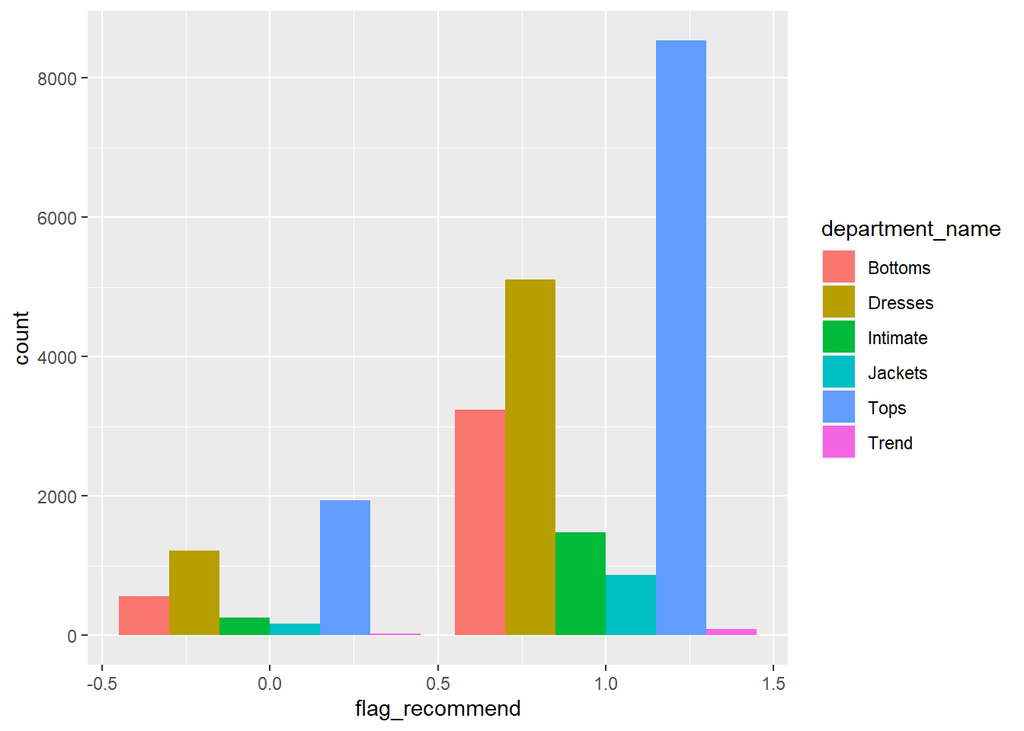

```r
ds %>% ggplot(aes(x=flag_recommend, fill=department_name)) + geom_bar(position = 'dodge')
```